# STAT 542 / CS 598: Homework 4

## Question 2 [30 Points] Second Step in Virtual Twins

Generate predictions on all data based on the best parameters from Question 1.

```r
set.seed(124)
all_data = mydata[,c(-1,-15)]

get_all_prediction <- function(therapy, mtry, nodesize){
  model.data = all_data[all_data[,"THERAPY"] == therapy,][,-2]
  rforest = randomForest(model.data$Health ~ . , data=model.data, mtry=mtry, nodesize=nodesize)
  return (predict(rforest, all_data))
}

get_all_treatment <- function(mtry, nodesize){
  pred.0 = get_all_prediction(0, mtry, nodesize)
  pred.1 = get_all_prediction(1, mtry, nodesize)
  return (ifelse(pred.1>pred.0, 1,0))
}

all_data['PRED'] = get_all_treatment(mtry=11, nodesize=100)
```

Build a single regression tree using the predicted values `all_data['PRED]` as the proposed treatment.

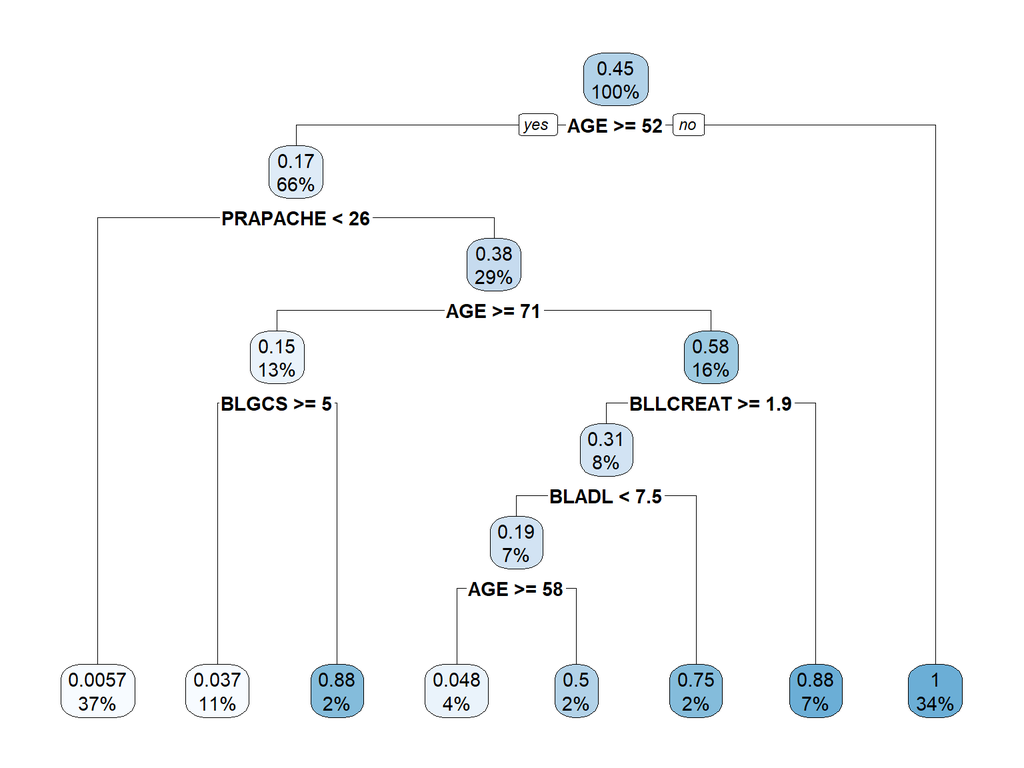

```r
par(mfrow=c(1,2))
require(rpart)
require(rpart.plot)
train.all_data = all_data[,c(-1,-2)]
rtree = rpart(train.all_data$PRED~., data=train.all_data)
par(mfrow=c(1,1))
rpart.plot(rtree)
```

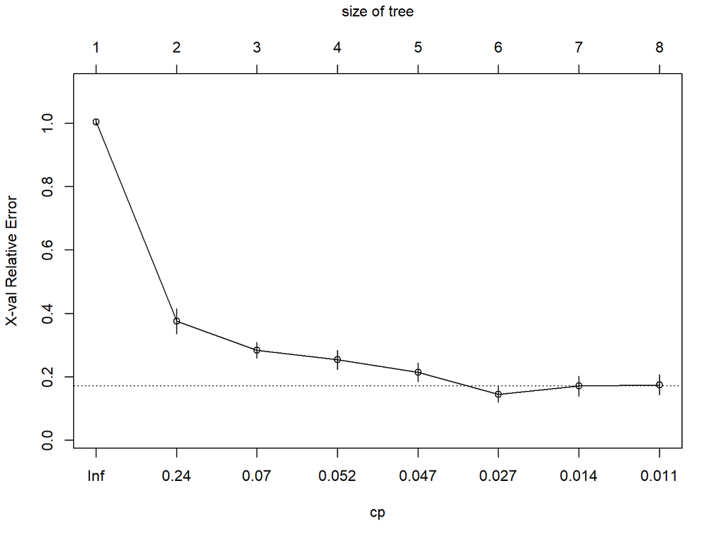

```r
plotcp(rtree)
```

This gives us a tree with the following CP values:

```
##
## Regression tree:
## rpart(formula = train.all_data$PRED ~ ., data = train.all_data)
##
## Variables actually used in tree construction:
## [1] AGE      BLADL    BLGCS    BLLCREAT PRAPACHE
##
## Root node error: 116.37/470 = 0.24761
##
## n= 470
##
##         CP nsplit rel error  xerror      xstd
## 1 0.628119      0   1.00000 1.00367 0.0091916
## 2 0.090654      1   0.37188 0.37572 0.0399637
## 3 0.053312      2   0.28123 0.28451 0.0247947
## 4 0.051545      3   0.22791 0.25387 0.0306802
## 5 0.042042      4   0.17637 0.21451 0.0299692
## 6 0.016919      5   0.13433 0.14535 0.0260048
## 7 0.011913      6   0.11741 0.17156 0.0316150
## 8 0.010000      7   0.10550 0.17483 0.0317182
```

To prune the tree, we find the amount of splits that minimise the cross validation error `xerror` as follows:

```r
opt = which.min(rtree$cptable[, "xerror"])
rtree$cptable[opt, 4]
```

```
## [1] 0.1453465
```

Find the upper limit based on 1 standard deviation and list all splits that have `xerror` less than this.

```r
upper_1se = rtree$cptable[opt, 4] + rtree$cptable[opt, 5]
tmp.id = which(rtree$cptable[, 4] <= upper_1se)
```

Compute an average `CP` value between the two splits with the lowest resulting `xerror` of `0.171` which shoudl fall between rows `5` and `6`:

```r
CP.1se = 0.5*(rtree$cptable[min(tmp.id[1]),1] + rtree$cptable[min(tmp.id[1])-1,1])
final.rtree = prune(rtree, cp=CP.1se)
```

which gives the following tree based on a $CP_{1se}$ of `0.029`.

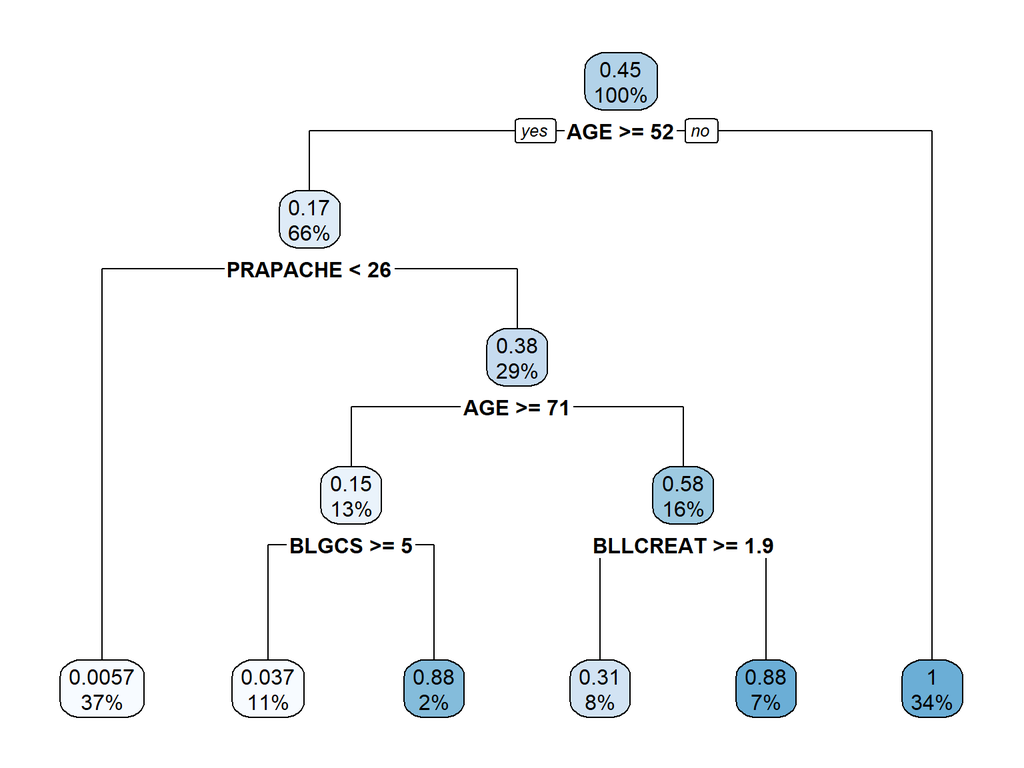

```r
par(mfrow=c(1,1))
rpart.plot(final.rtree)
```

```r
accuracy = get_accuracy(predict(final.rtree,newdata=train.all_data[,-12]),mydata$BEST)
accuracy
```

```
## [1] 0.312766
```